# Investigating Management Practices Across Countries and Industries

## Author: Alex Lucas

This project is a look into the management practices of schools, hospitals, and companies across many countries. Comparing the scores between a variety of different groups provided great insight into trends of management quality and where improvements can be made. This project is guided by [Doing Economics Empirical Project 6](https://www.core-econ.org/doing-economics/book/text/06-01.html) where the data is provided and questions are asked to provoke analytical thought. The two data files for this project can be accessed [here](https://www.mediafire.com/file/npu29mrnztsfaos/AMP_graph_manufacturing.csv/file) and [here](https://www.mediafire.com/file/c8ojmz0x62zhukw/AMP_graph_public.csv/file).

```python
import pandas as pd
import numpy as np
import matplotlib.pyplot as plt
import math
from IPython.display import display, HTML
import warnings
warnings.filterwarnings('ignore')
import os
```

# 6.1

1a. Briefly describe how the interviews with managers were conducted, and explain some methods the researchers used to improve the reliability and validity of their data.

The interviews with managers were conducted by MBA students who had business experience. They asked the managers open questions (rather than yes or no questions) on their management practices. Based on their answers, the interviewers gave them a score from 1 to 5, 1 being bad management practice and 5 being very good management practice. The interviewers did not tell the managers anything about the scoring system and the interviewers were not given any information about the companies beforehand. These measures along with a few others were put in place to remove bias in the results.

1b. Do you think that these are the best criteria for assessing management practices? What (if any) important aspects of management are not included in this assessment?

It was interesting to read about how different management practices can enhance productivity much more or much less depending on the environment of a company or even the culture of a company. One thing I thought of is that some employees could respond negatively to monitoring so more monitoring is not necessarily always better, which is a potential issue with the current methodology. Also, I think another factor that could be added is whether management is cultivating a positive or friendly environment. It can definitely enhance productivity if coworkers are friendly with each other and have a positive attitude towards their work.

2a) This is a table showing the average scores in each category for each country.

```python
# This code imports the file with the manufacturing data
manu_data = pd.read_csv('AMP_graph_manufacturing.csv')

#2a. This code creates a table that shows the mean of each of the management scores for each country.
mean_by_country = manu_data.groupby('country')[['management','monitor','target','people']].mean()
display(HTML(mean_by_country.to_html()))
```

| country | management | monitor | target | people |
| --- | --- | --- | --- | --- |
| Argentina | 2.760598 | 3.082731 | 2.681124 | 2.559572 |
| Australia | 3.018691 | 3.291837 | 3.015944 | 2.744813 |
| Brazil | 2.707565 | 3.058699 | 2.692970 | 2.552958 |
| Canada | 3.169578 | 3.547013 | 3.066753 | 2.944589 |
| Chile | 2.828426 | 3.141956 | 2.723659 | 2.668244 |
| China | 2.710497 | 2.901139 | 2.625737 | 2.693923 |
| France | 3.030195 | 3.427610 | 2.965905 | 2.737765 |
| Germany | 3.230104 | 3.567376 | 3.216486 | 2.978148 |
| Greece | 2.734583 | 2.969655 | 2.660558 | 2.577822 |
| India | 2.670248 | 2.913773 | 2.661319 | 2.634491 |
| Italy | 3.027487 | 3.261419 | 3.098501 | 2.763322 |
| Japan | 3.230012 | 3.501420 | 3.341193 | 2.920455 |
| Mexico | 2.919286 | 3.287831 | 2.881481 | 2.709700 |
| New Zealand | 2.928197 | 3.183019 | 2.960377 | 2.627358 |
| Poland | 2.896419 | 3.118803 | 2.940598 | 2.828395 |
| Portugal | 2.868672 | 3.265385 | 2.833603 | 2.586370 |
| Republic of Ireland | 2.887317 | 3.137736 | 2.807547 | 2.789308 |
| Sweden | 3.206483 | 3.641194 | 3.192139 | 2.833591 |
| UK | 3.034089 | 3.336959 | 2.978932 | 2.859420 |
| United States | 3.348413 | 3.576095 | 3.255497 | 3.247918 |

```python
#This code ranks each country's performance in each category and sorts them highest to lowest.
country_ranks = mean_by_country.rank(method='average', ascending=False).sort_values('management')
display(HTML(country_ranks.to_html()))
```

| country | management | monitor | target | people |
| --- | --- | --- | --- | --- |
| United States | 1.0 | 2.0 | 2.0 | 1.0 |
| Germany | 2.0 | 3.0 | 3.0 | 2.0 |
| Japan | 3.0 | 5.0 | 1.0 | 4.0 |
| Sweden | 4.0 | 1.0 | 4.0 | 6.0 |
| Canada | 5.0 | 4.0 | 6.0 | 3.0 |
| UK | 6.0 | 7.0 | 8.0 | 5.0 |
| France | 7.0 | 6.0 | 9.0 | 11.0 |
| Italy | 8.0 | 11.0 | 5.0 | 9.0 |
| Australia | 9.0 | 8.0 | 7.0 | 10.0 |
| New Zealand | 10.0 | 12.0 | 10.0 | 16.0 |
| Mexico | 11.0 | 9.0 | 12.0 | 12.0 |
| Poland | 12.0 | 15.0 | 11.0 | 7.0 |
| Republic of Ireland | 13.0 | 14.0 | 14.0 | 8.0 |
| Portugal | 14.0 | 10.0 | 13.0 | 17.0 |
| Chile | 15.0 | 13.0 | 15.0 | 14.0 |
| Argentina | 16.0 | 16.0 | 17.0 | 19.0 |
| Greece | 17.0 | 18.0 | 19.0 | 18.0 |
| China | 18.0 | 20.0 | 20.0 | 13.0 |
| Brazil | 19.0 | 17.0 | 16.0 | 20.0 |
| India | 20.0 | 19.0 | 18.0 | 15.0 |

**Do countries with a high overall rank also tend to rank highly on individual criteria?**

Yes, the countries with a high rank tend to rank highly on the individual criteria, which makes sense because the overall score is the average of the 3 individual scores.

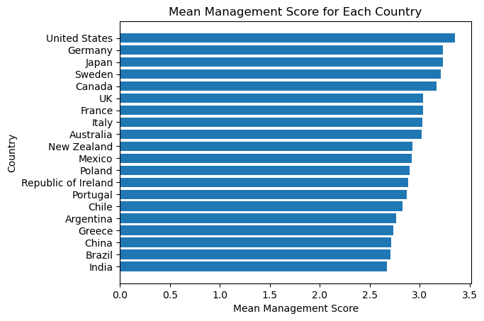

```python
#2b. This code creates a horizontal bar graph with the vertical axis being each country
# and the horizontal axis being each mean management score sorted from highest to lowest.
mean_management_score = manu_data.groupby('country')['management'].mean().sort_values().reset_index()
plt.barh(mean_management_score['country'],mean_management_score['management'])
plt.xlabel('Mean Management Score')
plt.ylabel('Country')
plt.title('Mean Management Score for Each Country')
```

**2c) Compare your chart with Figure 1 in Bloom et al. (2012). Can you explain why your chart is slightly different?** My chart is slightly different because the chart in Figure 1 on the Bloom et. al. paper includes all firms while my chart only includes firms in the manufacturing industry.

**3a)** This is a frequency table showing how many US firms fall into certain ranges of scores.

```python
#This code creates an array of numbers from 1 to 5 in increments of .2 to be referenced later as the bins.
range_of_scores = np.arange(1,5.2,.2)

#This code creates the frequency table for the US management scores with each column:
# "Ranges", "Frequency" and "Percentage of Firms"
US_scores = manu_data.loc[manu_data['country'] == 'United States', 'management']
frequency_US = US_scores.value_counts(bins=range_of_scores, sort=False)
percentage_of_firms_US = frequency_US/sum(frequency_US) * 100

US_frequency_table = pd.DataFrame(frequency_US)
US_frequency_table.insert(1,'% of Firms',percentage_of_firms_US)
US_frequency_table.rename(columns={"management": "Frequency"},inplace=True)
US_frequency_table.reset_index(inplace=True)
US_frequency_table.rename(columns={"index": "Ranges"},inplace=True)

display(HTML(US_frequency_table.to_html()))
```

|  | Ranges | Frequency | % of Firms |
| --- | --- | --- | --- |
| 0 | (0.999, 1.2] | 0 | 0.000000 |
| 1 | (1.2, 1.4] | 1 | 0.081633 |
| 2 | (1.4, 1.6] | 0 | 0.000000 |
| 3 | (1.6, 1.8] | 10 | 0.816327 |
| 4 | (1.8, 2.0] | 5 | 0.408163 |
| 5 | (2.0, 2.2] | 32 | 2.612245 |
| 6 | (2.2, 2.4] | 45 | 3.673469 |
| 7 | (2.4, 2.6] | 59 | 4.816327 |
| 8 | (2.6, 2.8] | 96 | 7.836735 |
| 9 | (2.8, 3.0] | 99 | 8.081633 |
| 10 | (3.0, 3.2] | 158 | 12.897959 |
| 11 | (3.2, 3.4] | 164 | 13.387755 |
| 12 | (3.4, 3.6] | 110 | 8.979592 |
| 13 | (3.6, 3.8] | 146 | 11.918367 |
| 14 | (3.8, 4.0] | 89 | 7.265306 |
| 15 | (4.0, 4.2] | 85 | 6.938776 |
| 16 | (4.2, 4.4] | 60 | 4.897959 |
| 17 | (4.4, 4.6] | 31 | 2.530612 |
| 18 | (4.6, 4.8] | 31 | 2.530612 |
| 19 | (4.8, 5.0] | 4 | 0.326531 |

This is a frequency table showing how many firms in Chile fall into certain ranges of scores.

```python
#This code creates the frequency table for the Chile management scores.
Chile_scores = manu_data.loc[manu_data['country'] == 'Chile', 'management']
frequency_Chile = Chile_scores.value_counts(bins=range_of_scores, sort=False)
percentage_of_firms_Chile = frequency_Chile/sum(frequency_Chile) * 100

Chile_frequency_table = pd.DataFrame(frequency_Chile)
Chile_frequency_table.insert(1,'% of Firms',percentage_of_firms_Chile)
Chile_frequency_table.rename(columns={"management": "Frequency"},inplace=True)

display(HTML(Chile_frequency_table.to_html()))
```

|  | Frequency | % of Firms |
| --- | --- | --- |
| (0.999, 1.2] | 0 | 0.000000 |
| (1.2, 1.4] | 1 | 0.315457 |
| (1.4, 1.6] | 3 | 0.946372 |
| (1.6, 1.8] | 6 | 1.892744 |
| (1.8, 2.0] | 18 | 5.678233 |
| (2.0, 2.2] | 21 | 6.624606 |
| (2.2, 2.4] | 30 | 9.463722 |
| (2.4, 2.6] | 25 | 7.886435 |
| (2.6, 2.8] | 49 | 15.457413 |
| (2.8, 3.0] | 42 | 13.249211 |
| (3.0, 3.2] | 38 | 11.987382 |
| (3.2, 3.4] | 27 | 8.517350 |
| (3.4, 3.6] | 21 | 6.624606 |
| (3.6, 3.8] | 20 | 6.309148 |
| (3.8, 4.0] | 6 | 1.892744 |
| (4.0, 4.2] | 9 | 2.839117 |
| (4.2, 4.4] | 1 | 0.315457 |
| (4.4, 4.6] | 0 | 0.000000 |
| (4.6, 4.8] | 0 | 0.000000 |
| (4.8, 5.0] | 0 | 0.000000 |

This is a frequency table showing how many firms in France fall into certain ranges of scores.

```python
#This code creates the frequency table for the France management scores.
France_scores = manu_data.loc[manu_data['country'] == 'France', 'management']
frequency_France = France_scores.value_counts(bins=range_of_scores, sort=False)
percentage_of_firms_France = frequency_France/sum(frequency_France) * 100

France_frequency_table = pd.DataFrame(frequency_France)
France_frequency_table.insert(1,'% of Firms',percentage_of_firms_France)
France_frequency_table.rename(columns={"management": "Frequency"},inplace=True)

display(HTML(France_frequency_table.to_html()))
```

|  | Frequency | % of Firms |
| --- | --- | --- |
| (0.999, 1.2] | 1 | 0.163132 |
| (1.2, 1.4] | 1 | 0.163132 |
| (1.4, 1.6] | 7 | 1.141925 |
| (1.6, 1.8] | 18 | 2.936378 |
| (1.8, 2.0] | 16 | 2.610114 |
| (2.0, 2.2] | 22 | 3.588907 |
| (2.2, 2.4] | 34 | 5.546493 |
| (2.4, 2.6] | 39 | 6.362153 |
| (2.6, 2.8] | 74 | 12.071778 |
| (2.8, 3.0] | 72 | 11.745514 |
| (3.0, 3.2] | 92 | 15.008157 |
| (3.2, 3.4] | 78 | 12.724307 |
| (3.4, 3.6] | 40 | 6.525285 |
| (3.6, 3.8] | 44 | 7.177814 |
| (3.8, 4.0] | 28 | 4.567700 |
| (4.0, 4.2] | 24 | 3.915171 |
| (4.2, 4.4] | 12 | 1.957586 |
| (4.4, 4.6] | 8 | 1.305057 |
| (4.6, 4.8] | 3 | 0.489396 |
| (4.8, 5.0] | 0 | 0.000000 |

This is a frequency table showing how many firms in Mexico fall into certain ranges of scores.

```python
#This code creates the frequency table for the Mexico management scores.
Mexico_scores = manu_data.loc[manu_data['country'] == 'Mexico', 'management']
frequency_Mexico = Mexico_scores.value_counts(bins=range_of_scores, sort=False)
percentage_of_firms_Mexico = frequency_Mexico/sum(frequency_Mexico) * 100

Mexico_frequency_table = pd.DataFrame(frequency_Mexico)
Mexico_frequency_table.insert(1,'% of Firms',percentage_of_firms_Mexico)
Mexico_frequency_table.rename(columns={"management": "Frequency"},inplace=True)
display(HTML(Mexico_frequency_table.to_html()))
```

|  | Frequency | % of Firms |
| --- | --- | --- |
| (0.999, 1.2] | 0 | 0.000000 |
| (1.2, 1.4] | 2 | 1.058201 |
| (1.4, 1.6] | 4 | 2.116402 |
| (1.6, 1.8] | 9 | 4.761905 |
| (1.8, 2.0] | 5 | 2.645503 |
| (2.0, 2.2] | 10 | 5.291005 |
| (2.2, 2.4] | 20 | 10.582011 |
| (2.4, 2.6] | 12 | 6.349206 |
| (2.6, 2.8] | 13 | 6.878307 |
| (2.8, 3.0] | 15 | 7.936508 |
| (3.0, 3.2] | 28 | 14.814815 |
| (3.2, 3.4] | 20 | 10.582011 |
| (3.4, 3.6] | 16 | 8.465608 |
| (3.6, 3.8] | 21 | 11.111111 |
| (3.8, 4.0] | 5 | 2.645503 |
| (4.0, 4.2] | 3 | 1.587302 |
| (4.2, 4.4] | 5 | 2.645503 |
| (4.4, 4.6] | 1 | 0.529101 |
| (4.6, 4.8] | 0 | 0.000000 |
| (4.8, 5.0] | 0 | 0.000000 |

3b) This is a histogram showing the percentage of firms in each range of scores comparing Chile vs. the US.

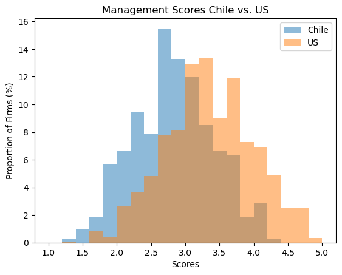

```python
#3b
#This code creates a histogram comparing Chile and the US. It shows the percentage of firms
# for each country that fall within each range of management score.
plt.figure()
Chile_proportion = np.ones(sum(frequency_Chile))/sum(frequency_Chile) * 100
Chile_histogram = Chile_scores.hist(bins = range_of_scores, weights=Chile_proportion,grid=False,alpha=0.5,label="Chile")

US_proportion = np.ones(sum(frequency_US))/sum(frequency_US) * 100
US_histogram = US_scores.hist(bins = range_of_scores, weights=US_proportion,grid=False,alpha=0.5,label="US")

plt.legend()
plt.xlabel("Scores")
plt.ylabel("Proportion of Firms (%)")
plt.title("Management Scores Chile vs. US")
```

This is a histogram showing the percentage of firms in each range of scores comparing France vs. the US.

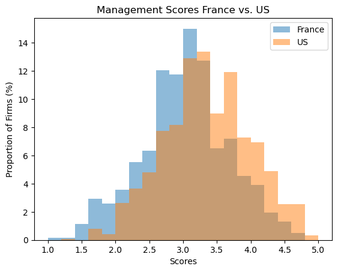

```python
#This code creates a histogram comparing France and US management scores.
plt.figure()
France_proportion = np.ones(sum(frequency_France))/sum(frequency_France) * 100
France_histogram = France_scores.hist(bins = range_of_scores, weights=France_proportion,grid=False,alpha=0.5,label="France")

US_proportion = np.ones(sum(frequency_US))/sum(frequency_US) * 100
US_histogram = US_scores.hist(bins = range_of_scores, weights=US_proportion,grid=False,alpha=0.5,label="US")

plt.legend()
plt.xlabel("Scores")
plt.ylabel("Proportion of Firms (%)")
plt.title("Management Scores France vs. US")
```

This is a histogram showing the percentage of firms in each range of scores comparing Mexico vs. the US.

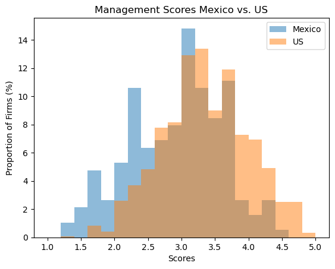

```python
#This code creates a histogram comparing Mexico and US management scores.
plt.figure()
Mexico_proportion = np.ones(sum(frequency_Mexico))/sum(frequency_Mexico) * 100
Mexico_histogram = Mexico_scores.hist(bins = range_of_scores, weights=Mexico_proportion,grid=False,alpha=0.5,label="Mexico")

US_proportion = np.ones(sum(frequency_US))/sum(frequency_US) * 100
US_histogram = US_scores.hist(bins = range_of_scores, weights=US_proportion,grid=False,alpha=0.5,label="US")

plt.legend()
plt.xlabel("Scores")
plt.ylabel("Proportion of Firms (%)")
plt.title("Management Scores Mexico vs. US")
```

**3c) Describe any visual similarities and differences between the distributions of your chosen countries and that of the US.**

**4a)** This is a box plot representing the management scores in the US.

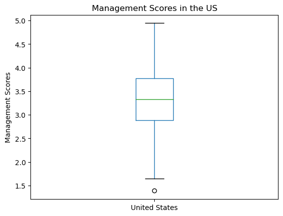

```python
plt.figure()

#This code creates a box plot for the US management scores.
#It visually represents the five-number summary of the US management scores data
df_US_scores = pd.DataFrame(US_scores)
df_US_scores = df_US_scores.rename(columns={"management": "United States"})
US_boxplot = df_US_scores.boxplot(grid=False)
plt.ylabel("Management Scores")
plt.title("Management Scores in the US")
```

This is a box plot representing the management scores in Chile.

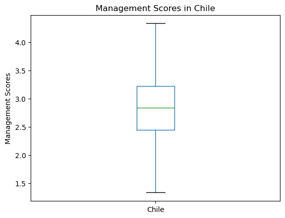

```python
#This code creates a box plot for Chile management scores.
plt.figure()
df_Chile_scores = pd.DataFrame(Chile_scores)
df_Chile_scores = df_Chile_scores.rename(columns={"management": "Chile"})
Chile_boxplot = df_Chile_scores.boxplot(grid=False)
plt.ylabel("Management Scores")
plt.title("Management Scores in Chile")
```

This is a box plot representing the management scores in France.

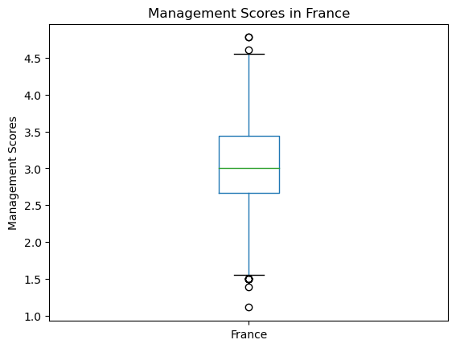

```python
#This code creates a box plot for France management scores.
plt.figure()
df_France_scores = pd.DataFrame(France_scores)
df_France_scores = df_France_scores.rename(columns={"management": "France"})
France_boxplot = df_France_scores.boxplot(grid=False)
plt.ylabel("Management Scores")
plt.title("Management Scores in France")
```

This is a box plot representing the management scores in Mexico.

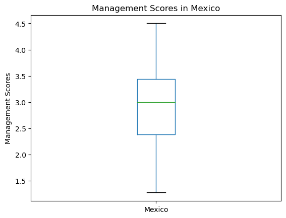

```python
#This creates a box plot for Mexico management scores.
plt.figure()
df_Mexico_scores = pd.DataFrame(Mexico_scores)
df_Mexico_scores = df_Mexico_scores.rename(columns={"management": "Mexico"})
Mexico_boxplot = df_Mexico_scores.boxplot(grid=False)
plt.ylabel("Management Scores")
plt.title("Management Scores in Mexico")
```

**4b) Use your box and whisker plots to add to your comparisons from Question 3(c).**

It seems like the US has the highest mean, upper quartile, and lower quartile which confirms what the histograms indicated. I think the box plots make it easier to visualize that Mexico has one of the largest spreads because the interquartile range, or the difference between the upper and lower quartile, seems to be the largest out of them all. However, France also appears to have a large spread because of the several outliers.

**5a)** This table shows the average management score for hospitals and schools by country.

```python
#This code reads the data for management scores in hospitals and schools.
hospital_school_data = pd.read_csv('AMP_graph_public.csv')
#This code creates a table for hospitals and schools that shows the mean of each of the management scores for each country.
mean_by_country_hs = hospital_school_data.groupby('country')[['management','monitoring','targets','people']].mean()

display(HTML(mean_by_country_hs.to_html()))
```

| country | management | monitoring | targets | people |
| --- | --- | --- | --- | --- |
| Canada | 2.642396 | 2.865644 | 2.635276 | 2.245194 |
| France | 2.404214 | 2.591772 | 2.289873 | 2.032700 |
| Germany | 2.586630 | 2.767766 | 2.520147 | 2.353480 |
| Italy | 2.479899 | 2.672289 | 2.330120 | 2.199799 |
| Sweden | 2.724242 | 3.027273 | 2.709091 | 2.459596 |
| UK | 2.874263 | 3.071429 | 2.806143 | 2.667800 |
| US | 2.874295 | 3.057680 | 2.756863 | 2.713780 |

This table shows the rank of each country in each scoring category for hospitals and schools.

```python
#This code creates a table for hospitals and schools that shows the rank of each country from highest to lowest.
country_ranks_hs = mean_by_country_hs.rank(method='average', ascending=False).sort_values('management')

display(HTML(country_ranks_hs.to_html()))
```

| country | management | monitoring | targets | people |
| --- | --- | --- | --- | --- |
| US | 1.0 | 2.0 | 2.0 | 1.0 |
| UK | 2.0 | 1.0 | 1.0 | 2.0 |
| Sweden | 3.0 | 3.0 | 3.0 | 3.0 |
| Canada | 4.0 | 4.0 | 4.0 | 5.0 |
| Germany | 5.0 | 5.0 | 5.0 | 4.0 |
| Italy | 6.0 | 6.0 | 6.0 | 6.0 |
| France | 7.0 | 7.0 | 7.0 | 7.0 |

**5b)Are the country rankings similar to those in manufacturing?** Yes, the scores for hospitals and schools are mostly similar with the US having the best overall management score, Sweden and Canada being close to each other, and France and Italy being comparable. The largest differences are the UK going from being below Germany, Sweden, and Canada in manufacturing, but above them all in the hospitals and schools ranking. In addition, Germany is second in the ranking for manufacturing, but moves down to 5th being below the UK, Sweden, and Canada in the hospitals and schools ranking.

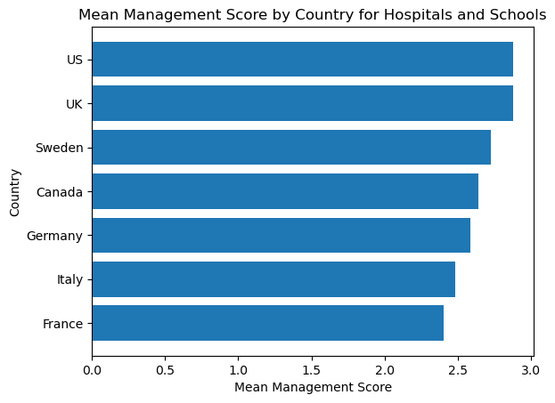

```python
#5b. This code creates a horizontal bar graph for hospitals and schools only with the vertical axis being each country
# and the horizontal axis being each mean management score sorted from highest to lowest.
plt.figure()
mean_management_score_hs = hospital_school_data.groupby('country')['management'].mean().sort_values().reset_index()
plt.barh(mean_management_score_hs['country'],mean_management_score_hs['management'])
plt.xlabel('Mean Management Score')
plt.ylabel('Country')
plt.title('Mean Management Score by Country for Hospitals and Schools')
```

**5c) Using your average criteria scores from Question 5(a), suggest some explanations for the observed rankings in either hospitals or schools.**

It makes sense that the United States is the highest scoring country from a pure management perspective in hospitals and schools because the U.S. has many policies of universal standardization. For example, in schools, common core laws require certain curricula to be taught and standardized tests to be taken throughout the country to make sure students are on track. This definitely increases the scores in every category for the US because students are monitored, given targets, and incentives throughout their schooling career.

In addition, a possible explanation for France being the lowest scoring country is that according to peoplesdispatch.org, the French healthcare system has been underfunded and neglected by the government. In France, healthcare is funded almost completely through tax revenue and managed by the government, so it’s possible that the government is worse at managing hospitals than private companies would be. This is interesting however, because the UK has a universal health care system and ranks much higher than France, so there may be other factors at play.

https://peoplesdispatch.org/2020/06/17/french-health-workers-hit-the-streets-demand-government-to-save-public-health-system/

# 6.2

**1a)** This is a table that gives a summary of the US, Australia, Japan, and Portugal showing the mean, standard deviation, and number of firms surveyed.

```python
#This code creates a summary table of manufacturing management scores for each country showing the
# mean, standard deviation, and number of firms surveyed.
management_score_summary = manu_data.groupby('country')['management'].aggregate(['mean','std'])
number_of_firms = (manu_data['country'].value_counts())

management_score_summary.insert(2, "# of Firms", number_of_firms)

country_score_summary = (management_score_summary.iloc[[19,1,11,15]])

display(HTML(country_score_summary.to_html()))
```

| country | mean | std | # of Firms |
| --- | --- | --- | --- |
| United States | 3.348413 | 0.642848 | 1225 |
| Australia | 3.018691 | 0.577252 | 392 |
| Japan | 3.230012 | 0.614942 | 176 |
| Portugal | 2.868672 | 0.626236 | 247 |

**1b)** Margin of error for each country: Z-score can be used because all sample sizes are greater than 100.

**United States**: 1.96(.642848/sqrt(1225)) = .0360  
**Australia**: 1.96(.577252/sqrt(392)) = .0572  
**Japan**: 1.96(.614942/sqrt(176)) = .0909  
**Portugal**: 1.96(.626236/sqrt(247)) = 0.0781

```python
#This code creates a bar plot for mean management scores and includes
#error bars to represent the 95% confidence interval.

labels = ['United States','Australia','Japan','Portugal']
x_pos = np.arange(len(labels))

#These are the mean scores for every country.
US_mean = country_score_summary['mean'].iloc[0]
Aus_mean = country_score_summary['mean'].iloc[1]
Japan_mean = country_score_summary['mean'].iloc[2]
Port_mean = country_score_summary['mean'].iloc[3]
means = [US_mean, Aus_mean, Japan_mean,Port_mean]
```

**1c)** This is a bar chart with the mean management scores and the error bars represent the 95% confidence interval.

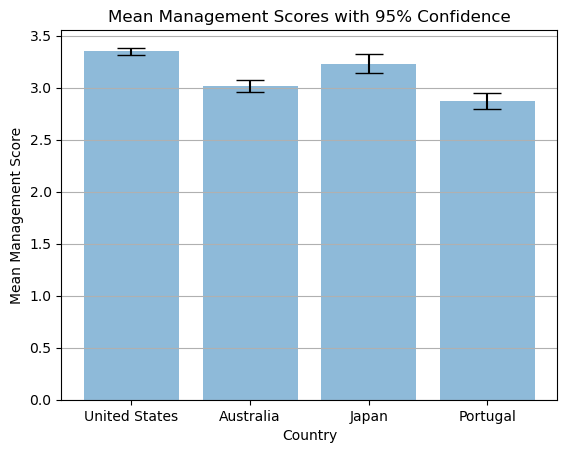

```python
#This is the size of the sample "n", or the number of firms, for each country.
US_n = (manu_data['country']=='United States').sum()
Aus_n = (manu_data['country']=='Australia').sum()
Japan_n = (manu_data['country']=='Japan').sum()
Port_n = (manu_data['country']=='Portugal').sum()

#This is the error calculated for each country using the margin of error formula.
US_error = 1.96*(country_score_summary['std'].iloc[0]/math.sqrt(US_n))
Aus_error = 1.96*(country_score_summary['std'].iloc[1]/math.sqrt(Aus_n))
Japan_error = 1.96*(country_score_summary['std'].iloc[2]/math.sqrt(Japan_n))
Port_error = 1.96*(country_score_summary['std'].iloc[3]/math.sqrt(Port_n))
error = [US_error, Aus_error, Japan_error, Port_error]

#This is the code setting up the bar plot.
fig, ax = plt.subplots()
ax.bar(x_pos, means, yerr = error, align='center', alpha=0.5, ecolor='black',capsize=10)
ax.set_xticks([0,1,2,3])
ax.set_xticklabels(labels)
ax.set_ylabel('Mean Management Score')
ax.set_xlabel('Country')
ax.set_title('Mean Management Scores with 95% Confidence')
ax.yaxis.grid(True)
```

**1d) Use the width of the confidence intervals to describe how precisely each mean was estimated.** For the US, the width of the confidence interval is narrow which shows the mean is estimated precisely. Australia’s is wider than the U.S., but narrower than Japan and Portugal’s, so Australia’s mean is estimated the second most precisely. Japan and Portugal have similarly wider margins of error than the US and Australia meaning their means are estimated less precisely.

**1e) Using your chart from Question 1(c) and the rule of thumb, what can you say about the differences between the US management score, and the scores of other countries? How would your results change if you use a different specified probability (for example, 99%)?**

The mean management score for the United States is estimated much more precisely than the other countries because it is a significantly larger sample size which allows the mean to be estimated better. If a 99% confidence interval was used, the margin of error would be greater for each country, but they would all be scaled the same so countries would not change in ranking of margin of error size.

```python
#This code creates a summary table of hospital and school management scores for each country showing the
# mean, standard deviation, and number of firms surveyed.
management_score_summary_hs = hospital_school_data.groupby('country')['management'].aggregate(['mean','std'])
number_of_firms_hs = (hospital_school_data['country'].value_counts())

management_score_summary_hs.insert(2, "# of Firms", number_of_firms_hs)
```

# 2b)

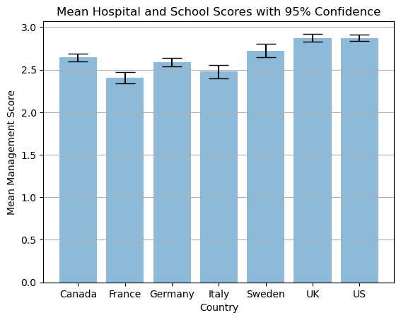

```python
#This code creates a bar plot for mean management scores for hospitals and schools
#and includes error bars to represent the 95% confidence interval.

labels_hs = ['Canada','France','Germany','Italy','Sweden','UK','US']
x_pos_hs = np.arange(len(labels_hs))

#These are the mean scores for every country for hospitals and schools.
Canada_mean_hs = management_score_summary_hs['mean'].iloc[0]
France_mean_hs = management_score_summary_hs['mean'].iloc[1]
Germany_mean_hs = management_score_summary_hs['mean'].iloc[2]
Italy_mean_hs = management_score_summary_hs['mean'].iloc[3]
Sweden_mean_hs = management_score_summary_hs['mean'].iloc[4]
UK_mean_hs = management_score_summary_hs['mean'].iloc[5]
US_mean_hs = management_score_summary_hs['mean'].iloc[6]

means_hs = [Canada_mean_hs, France_mean_hs, Germany_mean_hs,Italy_mean_hs, Sweden_mean_hs, UK_mean_hs,US_mean_hs]

#This is the size of the sample "n", or the number of hospitals and schools, for each country.
Canada_n_hs = (hospital_school_data['country']=='Canada').sum()
France_n_hs = (hospital_school_data['country']=='France').sum()
Germany_n_hs = (hospital_school_data['country']=='Germany').sum()
Italy_n_hs = (hospital_school_data['country']=='Italy').sum()
Sweden_n_hs = (hospital_school_data['country']=='Sweden').sum()
UK_n_hs = (hospital_school_data['country']=='UK').sum()
US_n_hs = (hospital_school_data['country']=='US').sum()

#This is the error calculated for each country using the margin of error formula.
Canada_error_hs = 1.96*(management_score_summary_hs['std'].iloc[0]/math.sqrt(Canada_n_hs))
France_error_hs = 1.96*(management_score_summary_hs['std'].iloc[1]/math.sqrt(France_n_hs))
Germany_error_hs = 1.96*(management_score_summary_hs['std'].iloc[2]/math.sqrt(Germany_n_hs))
Italy_error_hs = 1.96*(management_score_summary_hs['std'].iloc[3]/math.sqrt(Italy_n_hs))
Sweden_error_hs = 1.96*(management_score_summary_hs['std'].iloc[4]/math.sqrt(Sweden_n_hs))
UK_error_hs = 1.96*(management_score_summary_hs['std'].iloc[5]/math.sqrt(UK_n_hs))
US_error_hs = 1.96*(management_score_summary_hs['std'].iloc[6]/math.sqrt(US_n_hs))
error_hs = [Canada_error_hs, France_error_hs, Germany_error_hs,Italy_error_hs,Sweden_error_hs, UK_error_hs,US_error_hs]

#This is the code setting up the bar plot for hospitals and schools.
fig_hs, ax_hs = plt.subplots()
ax_hs.bar(x_pos_hs, means_hs, yerr = error_hs, align='center', alpha=0.5, ecolor='black',capsize=10)
ax_hs.set_xticks([0,1,2,3,4,5,6])
ax_hs.set_xticklabels(labels_hs)
ax_hs.set_ylabel('Mean Management Score')
ax_hs.set_xlabel('Country')
ax_hs.set_title('Mean Hospital and School Scores with 95% Confidence')
ax_hs.yaxis.grid(True)
```

**Are there any countries for which you can be confident that management practices are either better, or worse, on average than in the US? Explain your answer.** You can be almost completely certain that Canada, France, Germany, and Italy, have a lower true population mean score than the US because the upper bound of their confidence intervals are still lower than the lower bound of the US confidence interval. However, there is still a small chance that the true US mean score is lower than its confidence interval and a small chance that each of the mentioned countries could have a true mean score higher than their confidence interval.

**3) Look at the width of your confidence intervals and the corresponding standard deviation and number of observations for each one. Explain whether or not the relationship between them is what you would expect.**

# 6.3

**1a)** This is a table that shows the mean, standard deviation, and number of firms for each country, ownership type, and institution type for schools and hospitals only.

```python
#1a. This code creates a table showing the mean, standard deviation, and count
#for private or public hospitals or schools in each country.
ownership_score_summary_hs = hospital_school_data.groupby(['country','ownership','ind'])['management'].aggregate(['mean','std','count'])
print(ownership_score_summary_hs)
```

```
                                 mean       std  count
country ownership ind
Canada  Other     Schools    3.150000       NaN      1
        Private   Hospitals  2.775000  0.787930      4
                  Schools    2.756516  0.452592     21
        Public    Hospitals  2.518129  0.445888    171
                  Schools    2.780498  0.384610    129
France  Private   Hospitals  2.653289  0.507474     20
        Public    Hospitals  2.368116  0.407769    138
Germany Private   Hospitals  2.605147  0.385961     68
                  Schools    2.734375  0.488098     16
        Public    Hospitals  2.679032  0.384915     62
                  Schools    2.512992  0.412176    127
Italy   Private   Hospitals  2.712520  0.501191     33
        Public    Hospitals  2.422180  0.509360    133
Sweden  Private   Hospitals  3.100000  0.070711      2
                  Schools    3.069565  0.630068     23
        Public    Hospitals  2.540244  0.433333     41
                  Schools    2.706818  0.312297     66
UK      Private   Hospitals  2.998438  0.394905     64
                  Schools    2.890909  0.411593     11
        Public    Hospitals  2.731250  0.418584    120
                  Schools    2.965488  0.396379     99
US      Private   Hospitals  3.138415  0.529921    164
                  Schools    2.656223  0.480229     74
        Public    Hospitals  2.869939  0.523831    163
                  Schools    2.748853  0.439793    211
```

**1b)** These are the confidence interval widths for public and private hospitals.

```python
#1b This code calculates the confidence interval widths for both hospitals and schools and
#puts them in a table.
hospitals = ownership_score_summary_hs.iloc[[1,3,5,6,7,9,11,12,13,15,17,19,21,23],:]
schools =  ownership_score_summary_hs.iloc[[2,4,8,10,14,16,18,20,22,24],:]

confidence_interval_hospitals = 1.96*(hospitals.iloc[:,1]/np.sqrt(hospitals.iloc[:,2]))
hospitals['Confidence Interval Width'] = confidence_interval_hospitals

confidence_interval_schools = 1.96*(schools.iloc[:,1]/np.sqrt(schools.iloc[:,2]))
schools['Confidence Interval Width'] = confidence_interval_schools
```

These are the confidence interval widths for public and private hospitals.

```python
print(confidence_interval_hospitals)
```

```
country  ownership  ind
Canada   Private    Hospitals    0.772171
         Public     Hospitals    0.066832
France   Private    Hospitals    0.222410
         Public     Hospitals    0.068035
Germany  Private    Hospitals    0.091737
         Public     Hospitals    0.095813
Italy    Private    Hospitals    0.171002
         Public     Hospitals    0.086568
Sweden   Private    Hospitals    0.098000
         Public     Hospitals    0.132643
UK       Private    Hospitals    0.096752
         Public     Hospitals    0.074894
US       Private    Hospitals    0.081105
         Public     Hospitals    0.080418
dtype: float64
```

These are the confidence interval widths for public and private schools.

```python
print(confidence_interval_schools)
```

```
country  ownership  ind
Canada   Private    Schools    0.193577
         Public     Schools    0.066371
Germany  Private    Schools    0.239168
         Public     Schools    0.071686
Sweden   Private    Schools    0.257502
         Public     Schools    0.075345
UK       Private    Schools    0.243236
         Public     Schools    0.078082
US       Private    Schools    0.109418
         Public     Schools    0.059342
dtype: float64
```

**1c)** This is the bar plot showing the mean management scores for public and private hospitals with 95% confidence.

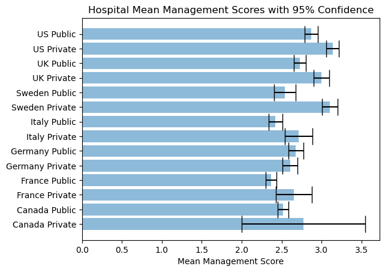

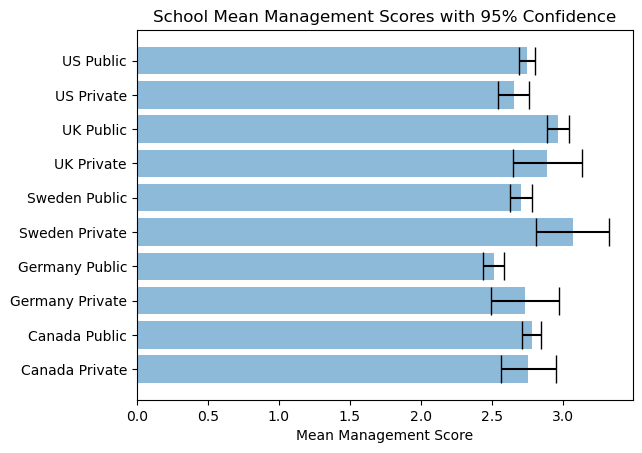

```python
#This code creates a bar plot for mean scores for public and private hospitals.
labels2 = ['Canada Private','Canada Public','France Private','France Public','Germany Private','Germany Public','Italy Private','Italy Public','Sweden Private','Sweden Public','UK Private','UK Public','US Private', 'US Public']
means2 = hospitals.iloc[:,0]
x_pos2 = np.arange(len(means2))


fig2, ax2 = plt.subplots()
ax2.barh(x_pos2, means2, xerr = confidence_interval_hospitals, align='center', alpha=0.5, ecolor='black',capsize=10)
ax2.set_yticklabels(labels2)
ax2.set_yticks([0,1,2,3,4,5,6,7,8,9,10,11,12,13])
ax2.set_xlabel('Mean Management Score')
ax2.set_title('Hospital Mean Management Scores with 95% Confidence')

#This code creates a bar plot for mean scores for public and private schools.

labels3 = ['Canada Private','Canada Public','Germany Private','Germany Public','Sweden Private','Sweden Public','UK Private','UK Public','US Private', 'US Public']
means3 = schools.iloc[:,0]
x_pos3 = np.arange(len(means3))

fig3, ax3 = plt.subplots()
ax3.barh(x_pos3,means3,xerr=confidence_interval_schools,align='center', alpha=0.5, ecolor='black',capsize=10)
ax3.set_yticklabels(labels3)
ax3.set_yticks([0,1,2,3,4,5,6,7,8,9])
ax3.set_xlabel('Mean Management Score')
ax3.set_title('School Mean Management Scores with 95% Confidence')
```

This is the bar plot showing the mean management scores for public and private schools with 95% confidence.

**Describe the differences between public and private firms within countries and compare management scores for the same firm type across countries. (For example, is one type of firm generally better managed than the other? Are there similar patterns for hospitals and schools?**

```python
#2a. This code puts a new column in manufacturing data showing the firm size.
firm_size = np.where(manu_data['sic']<330,"Small", "Large")

manu_data['size']=firm_size.tolist()
```

```python
#2b This code creates a table for US, Argentina, and Australia grouped by country, ownership, and size

size_summary = manu_data.groupby(['country','ownership','size'])['management'].aggregate(['mean','std','count'])

size_summary_countries = size_summary.loc[['United States','Argentina','Australia']]

display(HTML(size_summary.to_html()))
```

| country | ownership | size | mean | std | count |
| --- | --- | --- | --- | --- | --- |
| Argentina | Dispersed Shareholders | Large | 3.365079 | 0.726553 | 14 |
|  |  | Small | 3.146465 | 0.725263 | 33 |
|  | Family owned, external CEO | Large | 3.166667 | 0.305976 | 7 |
|  |  | Small | 2.965278 | 0.683606 | 8 |
|  | Family owned, family CEO | Large | 2.709150 | 0.595291 | 17 |
|  |  | Small | 2.520202 | 0.621878 | 33 |
|  | Founder | Large | 2.577161 | 0.613968 | 18 |
|  |  | Small | 2.349003 | 0.585723 | 39 |
|  | Government | Large | 3.638889 | 1.610632 | 2 |
|  |  | Small | 3.055556 | NaN | 1 |
|  | Other | Large | 3.039683 | 0.867636 | 7 |
|  |  | Small | 2.625926 | 0.602927 | 15 |
|  | Private Equity | Small | 3.222222 | NaN | 1 |
|  | Private Individuals | Large | 2.760684 | 0.713042 | 13 |
|  |  | Small | 2.761518 | 0.703304 | 41 |
| Australia | Dispersed Shareholders | Large | 3.197531 | 0.661619 | 72 |
|  |  | Small | 3.106111 | 0.536607 | 100 |
|  | Family owned, external CEO | Large | 3.144444 | 0.224296 | 5 |
|  |  | Small | 3.611111 | 0.413258 | 4 |
|  | Family owned, family CEO | Large | 3.079861 | 0.606199 | 16 |
|  |  | Small | 2.992410 | 0.532962 | 31 |
|  | Founder | Large | 2.717391 | 0.433875 | 23 |
|  |  | Small | 2.629630 | 0.597122 | 15 |
|  | Government | Large | 3.666667 | NaN | 1 |
|  |  | Small | 2.805556 | 0.274986 | 2 |
|  | Managers | Large | 2.583334 | 0.746390 | 2 |
|  |  | Small | 3.166667 | NaN | 1 |
|  | Other | Large | 3.252137 | 0.494109 | 13 |
|  |  | Small | 2.898990 | 0.480250 | 22 |
|  | Private Equity | Large | 2.644445 | 0.814225 | 5 |

[output cut: 300 more lines]

```python
#2c.
display(HTML(size_summary_countries.to_html()))

#This code calculates the confidence interval width for each firm type in each country.
confidence_interval_countries = 1.96*(size_summary_countries.iloc[:,1]/np.sqrt(size_summary_countries.iloc[:,2]))
```

| country | ownership | size | mean | std | count |
| --- | --- | --- | --- | --- | --- |
| United States | Dispersed Shareholders | Large | 3.504063 | 0.571173 | 293 |
|  |  | Small | 3.437398 | 0.542764 | 160 |
|  | Family owned, external CEO | Large | 3.617350 | 0.504799 | 11 |
|  |  | Small | 3.138024 | 0.596900 | 17 |
|  | Family owned, family CEO | Large | 3.202451 | 0.680017 | 62 |
|  |  | Small | 3.058122 | 0.683909 | 53 |
|  | Founder | Large | 3.288292 | 0.611181 | 42 |
|  |  | Small | 3.009591 | 0.508079 | 46 |
|  | Government | Small | 4.055555 | NaN | 1 |
|  | Managers | Large | 3.436508 | 0.703042 | 7 |
|  |  | Small | 4.033333 | 0.494725 | 5 |
|  | Other | Large | 3.374613 | 0.619592 | 19 |
|  |  | Small | 3.276292 | 0.633149 | 33 |
|  | Private Equity | Large | 3.394097 | 0.475685 | 32 |
|  |  | Small | 3.450535 | 0.437718 | 22 |
|  | Private Individuals | Large | 3.198643 | 0.658004 | 73 |
|  |  | Small | 3.213829 | 0.667455 | 88 |
| Argentina | Dispersed Shareholders | Large | 3.365079 | 0.726553 | 14 |
|  |  | Small | 3.146465 | 0.725263 | 33 |
|  | Family owned, external CEO | Large | 3.166667 | 0.305976 | 7 |
|  |  | Small | 2.965278 | 0.683606 | 8 |
|  | Family owned, family CEO | Large | 2.709150 | 0.595291 | 17 |
|  |  | Small | 2.520202 | 0.621878 | 33 |
|  | Founder | Large | 2.577161 | 0.613968 | 18 |
|  |  | Small | 2.349003 | 0.585723 | 39 |
|  | Government | Large | 3.638889 | 1.610632 | 2 |
|  |  | Small | 3.055556 | NaN | 1 |
|  | Other | Large | 3.039683 | 0.867636 | 7 |
|  |  | Small | 2.625926 | 0.602927 | 15 |
|  | Private Equity | Small | 3.222222 | NaN | 1 |
|  | Private Individuals | Large | 2.760684 | 0.713042 | 13 |
|  |  | Small | 2.761518 | 0.703304 | 41 |
| Australia | Dispersed Shareholders | Large | 3.197531 | 0.661619 | 72 |
|  |  | Small | 3.106111 | 0.536607 | 100 |
|  | Family owned, external CEO | Large | 3.144444 | 0.224296 | 5 |
|  |  | Small | 3.611111 | 0.413258 | 4 |
|  | Family owned, family CEO | Large | 3.079861 | 0.606199 | 16 |
|  |  | Small | 2.992410 | 0.532962 | 31 |
|  | Founder | Large | 2.717391 | 0.433875 | 23 |
|  |  | Small | 2.629630 | 0.597122 | 15 |
|  | Government | Large | 3.666667 | NaN | 1 |
|  |  | Small | 2.805556 | 0.274986 | 2 |
|  | Managers | Large | 2.583334 | 0.746390 | 2 |
|  |  | Small | 3.166667 | NaN | 1 |
|  | Other | Large | 3.252137 | 0.494109 | 13 |
|  |  | Small | 2.898990 | 0.480250 | 22 |
|  | Private Equity | Large | 2.644445 | 0.814225 | 5 |
|  |  | Small | 2.714286 | 0.392088 | 7 |
|  | Private Individuals | Large | 3.010530 | 0.617345 | 27 |
|  |  | Small | 2.851449 | 0.502675 | 46 |

**2d)** This is a bar graph showing the mean management scores for each firm type in the United States.

[figure not shown]

```python
#2d.
# This code creates a bar plot for the United States showing the mean management score for each firm type.


labels4 = ['Dispersed Shareholders, Large', 'Dispersed Shareholders, Small', 'Family owned, external CEO, Large', 'Family owned, external CEO, Small',
           'Family owned family CEO, Large', 'Family owned family CEO, Small','Founder, Large’, ‘Founder, Small',
           'Government, Small', 'Managers, Large', 'Managers, Small', 'Other, Large', 'Other, Small', 'Private Equity, Large', 'Private Equity, Small',
           'Private Individuals, Large','Private Individuals, Small']
means4 = size_summary_countries['mean'].iloc[0:16]
x_pos4 = np.arange(len(means4))

fig4, ax4 = plt.subplots()
ax4.barh(x_pos4,means4,xerr=confidence_interval_countries.iloc[0:16],align='center', alpha=0.5, ecolor='black',capsize=10)
ax4.set_yticklabels(labels4)
ax4.set_yticks([0,1,2,3,4,5,6,7,8,9,10,11,12,13,14,15,16])
ax4.set_ylabel('Firm Type')
ax4.set_xlabel('Mean Management Score')
ax4.set_title('United States Mean Management Scores with 95% Confidence')
```

This is a bar graph showing the mean management scores for each firm type in the Argentina.

[figure not shown]

```python
# This code creates a bar plot for Argentina showing the mean management score for each firm type.

labels5 = ['Dispersed Shareholders, Large', 'Dispersed Shareholders, Small', 'Family owned, external CEO, Large', 'Family owned, external CEO, Small',
           'Family owned family CEO, Large', 'Family owned family CEO, Small','Founder, Large’, ‘Founder, Small', 'Government, Large',
           'Government, Small', 'Other, Large', 'Other, Small', 'Private Equity, Small',
           'Private Individuals, Large','Private Individuals, Small']
means5 = size_summary_countries['mean'].iloc[17:31]
x_pos5 = np.arange(len(means5))

fig5, ax5 = plt.subplots()
ax5.barh(x_pos5,means5,xerr=confidence_interval_countries.iloc[17:31],align='center', alpha=0.5, ecolor='black',capsize=10)
ax5.set_yticklabels(labels5)
ax5.set_yticks([0,1,2,3,4,5,6,7,8,9,10,11,12,13,14])
ax5.set_ylabel('Firm Type')
ax5.set_xlabel('Mean Management Score')
ax5.set_title('Argentina Mean Management Scores with 95% Confidence')
```

This is a bar graph showing the mean management scores for each firm type in Australia.

[figure not shown]

```python
# This code creates a bar plot for the Australia showing the mean management score for each firm type.
labels6 = ['Dispersed Shareholders, Large', 'Dispersed Shareholders, Small', 'Family owned, external CEO, Large', 'Family owned, external CEO, Small',
           'Family owned family CEO, Large', 'Family owned family CEO, Small','Founder, Large’, ‘Founder, Small', 'Government, Large',
           'Government, Small','Managers, Large', 'Managers,Small', 'Other, Large', 'Other, Small', 'Private Equity, Large','Private Equity, Small',
           'Private Individuals, Large','Private Individuals, Small']
means6 = size_summary_countries['mean'].iloc[32:49]
x_pos6 = np.arange(len(means6))

fig6, ax6 = plt.subplots()
ax6.barh(x_pos6,means6,xerr=confidence_interval_countries.iloc[32:49],align='center', alpha=0.5, ecolor='black',capsize=10)
ax6.set_yticklabels(labels6)
ax6.set_yticks([0,1,2,3,4,5,6,7,8,9,10,11,12,13,14,15,16])
ax6.set_ylabel('Firm Type')
ax6.set_xlabel('Mean Management Score')
ax6.set_title('Australia Mean Management Scores with 95% Confidence')
```

**3. For each of the following variables, explain how it could affect management practices, and then explain how management practices could affect it: education level of managers (percentage with a college degree) number of competitors firm size (number of employees).**

Increasing education level of managers can definitely improve management practices because managers with formal training in business will have a better idea of proven organization methods such as monitoring and setting targets and incentives than those that are not educated.

Increasing the number of competitors could mean the market attracts more talented managers which would increase the management score. However, an increasing number of competitors could also mean that there are many new firms entering the market with poor management, which could decrease management scores. A market with less competitors could have high management scores if the market is controlled by a few large corporations with good management.

Higher firm sizes could mean that the companies are able to pay higher salaries and attract better management talent, which would increase management score. However, large firms are also more difficult to manage because there are more people and moving parts, so this could also decrease management scores.

**4. Briefly describe the idea behind a randomized field experiment, and explain, with reference to the results of the experiment in India, whether we can use it to determine the direction of causation between management practice and firm performance.**

A randomized field experiment is an experiment where a group of companies is selected randomly to be given a treatment, and their results are compared to a randomly selected control group that is not given any treatment. This is a way to show that the treatment can have a strong correlation towards a certain effect on management practices. Generally, more research is needed to determine whether there is a causal effect however.

**Figure 12 in the paper shows productivity in treatment and control firms over time, with 95% confidence intervals. Use the information in the chart to describe the effect of the treatment on firm productivity.**

The treatment seems to have a positive correlation with increased productivity over time because the treatment group increases at a higher rate than the control plans and the difference between the two grows larger and larger. It seems that the effect of the treatment had smaller effects in the short-term, but greater effects in the long term because the productivity for the treatment group is increasing at an increasing rate as time goes on.